# Aquaculture in Vietnam

Minh Chau

2025-01-13

```r
#this is a data base about value of aquatic products per hectare. time from 2016 to 2022.
#link for this data: https://www.gso.gov.vn/px-web-2/?pxid=V0603&theme=N%C3%B4ng%2C%20l%C3%A2m%20nghi%E1%BB%87p%20v%C3%A0%20th%E1%BB%A7y%20s%E1%BA%A3n
# Read the Excel file
data_01 <- read_excel("C:/Users/ngoti/Desktop/Economic in Aquaculture/file_01.xlsx")
```

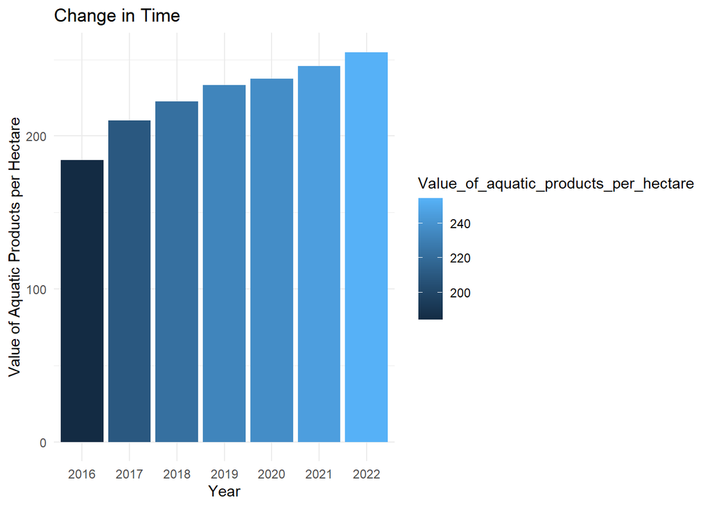

```r
# Subset the data: Select rows where the second column (year) is >= 2016 and choose relevant columns
data_01_c <- data_01 %>%
  filter(...2 >= 2016) %>%
  select(...2, ...3)

# Rename columns for clarity
colnames(data_01_c) <- c("year", "Value_of_aquatic_products_per_hectare")

# Convert the value column to numeric
data_01_c$Value_of_aquatic_products_per_hectare <- as.numeric(data_01_c$Value_of_aquatic_products_per_hectare)

# --- Create Bar Plot ---
ggplot(data_01_c, aes(x = year, y = Value_of_aquatic_products_per_hectare, fill = Value_of_aquatic_products_per_hectare)) +
  geom_bar(stat = "identity") +
  labs(
    title = "Change in Time",
    x = "Year",
    y = "Value of Aquatic Products per Hectare"
  ) +
  theme_minimal()
```

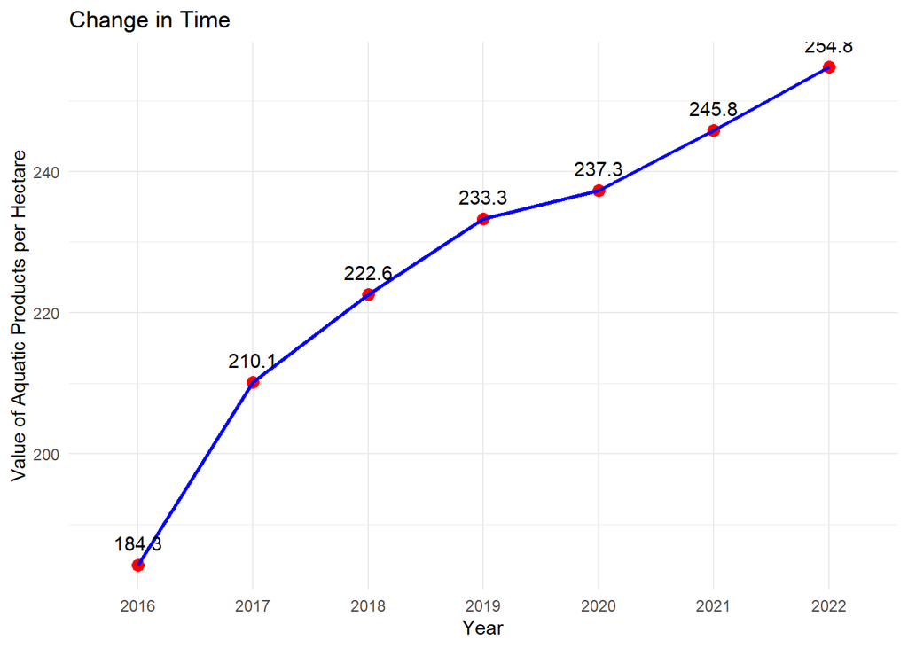

```r
# --- Create Line Plot ---
ggplot(data_01_c, aes(x = year, y = Value_of_aquatic_products_per_hectare, group = 1)) +
  geom_point(size = 3, color = "red") +
  geom_line(linewidth = 1, color = "blue") +
  geom_text(aes(label = Value_of_aquatic_products_per_hectare), vjust = -1, color = "black") +  # Add labels
  labs(
    title = "Change in Time",
    x = "Year",
    y = "Value of Aquatic Products per Hectare"
  ) +
  theme_minimal()
```

```r
# --- Compare Each Year with Previous Year (2016 as 100%) ---
data_01_c <- data_01_c %>%
  mutate(increase_lvl = ifelse(row_number() == 1, 1, Value_of_aquatic_products_per_hectare / lag(Value_of_aquatic_products_per_hectare)))

# Convert increase level to formatted numeric values
data_01_c$increase_lvl <- round(as.numeric(data_01_c$increase_lvl), 3)

# Print updated dataset
print(data_01_c)
```

```
## # A tibble: 7 × 3
##   year  Value_of_aquatic_products_per_hectare increase_lvl
##   <chr>                                 <dbl>        <dbl>
## 1 2016                                   184.         1
## 2 2017                                   210.         1.14
## 3 2018                                   223.         1.06
## 4 2019                                   233.         1.05
## 5 2020                                   237.         1.02
## 6 2021                                   246.         1.04
## 7 2022                                   255.         1.04
```

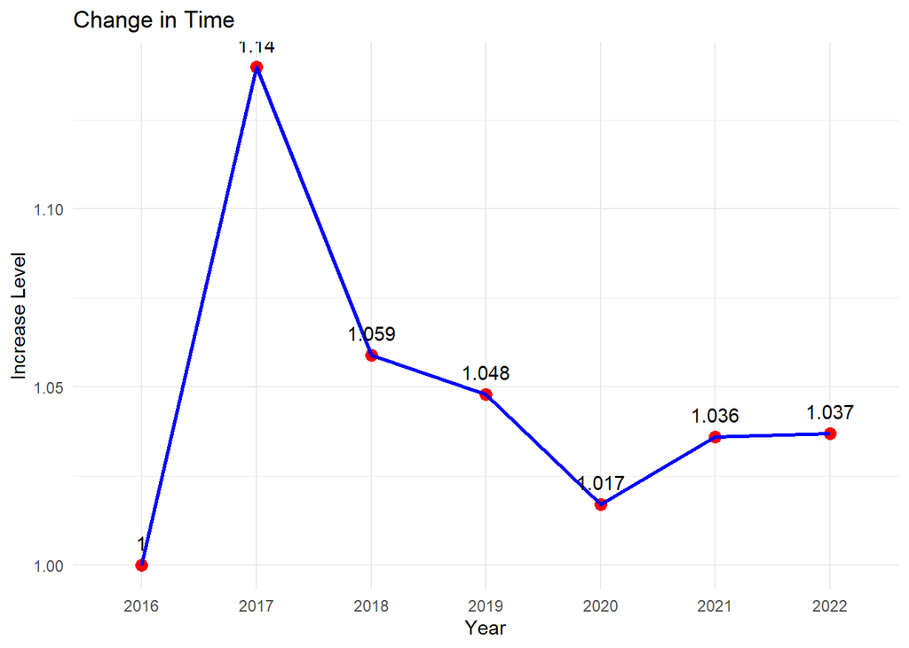

```r
# --- Create Line Plot for Increase Level ---
ggplot(data_01_c, aes(x = year, y = increase_lvl, group = 1)) +
  geom_point(size = 3, color = "red") +
  geom_line(linewidth = 1, color = "blue") +
  geom_text(aes(label = increase_lvl), vjust = -1, color = "black") +  # Add labels
  labs(
    title = "Change in Time",
    x = "Year",
    y = "Increase Level"
  ) +
  theme_minimal()
```

#Summary chunk 1 Nam nao gia tri tren 1 hecta dat nuoi trong thu hoach thuy san deu tang. Cong thuc tinh la tu san luong tinh ra tien roi chia cho dien tich. Vay thi no se phu thuoc vao 2 yeu to do la san luong thu duoc va dien tich.

Cau hoi dat ra: Voi gia tri deu tang nhu vay thi san luon va dien tich thay doi nhu the nao?

```r
# insert data from this link: https://www.gso.gov.vn/px-web-2/?pxid=V0656&theme=N%C3%B4ng%2C%20l%C3%A2m%20nghi%E1%BB%87p%20v%C3%A0%20th%E1%BB%A7y%20s%E1%BA%A3n

#from 2022, the survey is count on the area that harvest

# Read the Excel file
data_02 <- read_excel("C:/Users/ngoti/Desktop/Economic in Aquaculture/file_02.xlsx")
# Select the relevant rows and columns
data_02_c <- data_02[2:12, 1:8]

# Rename the first cell to "Year"
data_02_c[1, 1] <- "Year"

# Set column names
colnames(data_02_c) <- c("type", 2016:2022)

# Convert text to ASCII format for consistency
data_02_c$type <- stri_trans_general(data_02_c$type, "Latin-ASCII")

# Rename "Year" to avoid conflicts
data_02_c <- data_02_c %>%
  mutate(type = ifelse(type == "Year", "Year_Column", type))

# Convert 'type' column into row names, then transpose the data
data_02_c <- data_02_c %>%
  column_to_rownames(var = "type") %>%
  t() %>%
  as.data.frame() %>%
  rownames_to_column(var = "Year")

# Remove "Year" column
data_02_c <- select(data_02_c, -Year)
colnames(data_02_c)[3]<- "Thuy san bien"

# Print final cleaned dataset
print(data_02_c)
```

```
##   Year_Column TONG SO Thuy san bien Nuoi ca (thuy san bien)
## 1        2016  1071.4            46                     0.6
## 2        2017  1105.2          48.2                     0.6
## 3        2018  1125.9          45.2                     0.5
## 4        2019  1146.1          44.5                     0.6
## 5        2020  1125.3          41.9                     0.5
## 6        2021  1089.5          37.3                     0.4
## 7        2022  1097.7          40.7                     1.1
##   Nuoi tom (thuy san bien) Nuoi hon hop va thuy san khac (thuy san bien)
## 1                      3.4                                            42
## 2                      2.5                                          45.1
## 3                      2.4                                          42.3
## 4                      2.4                                          41.5
## 5                      2.5                                          38.9
## 6                      0.3                                          36.6
```

[output cut: 25 more lines]

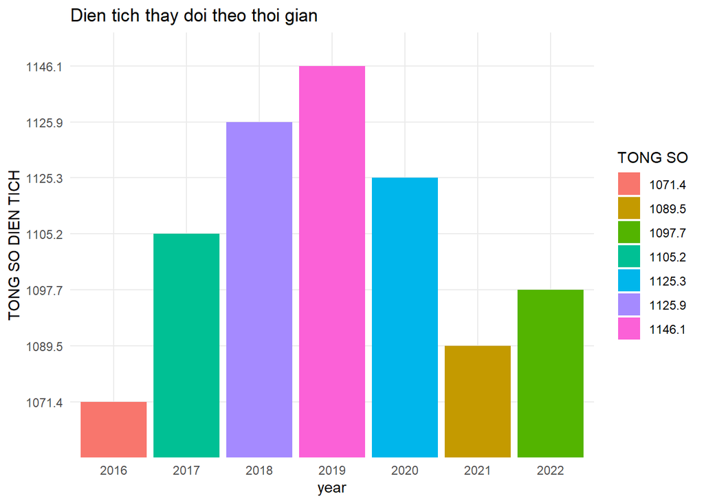

```r
#creat a bar plot for TONG SO
ggplot(data_02_c,aes(x=Year_Column,y = `TONG SO`,fill = `TONG SO`)) +
  geom_bar(stat = "identity") +
  labs(title = "Dien tich thay doi theo thoi gian",
  x ="year",
  y = "TONG SO DIEN TICH") +
  theme_minimal()
```

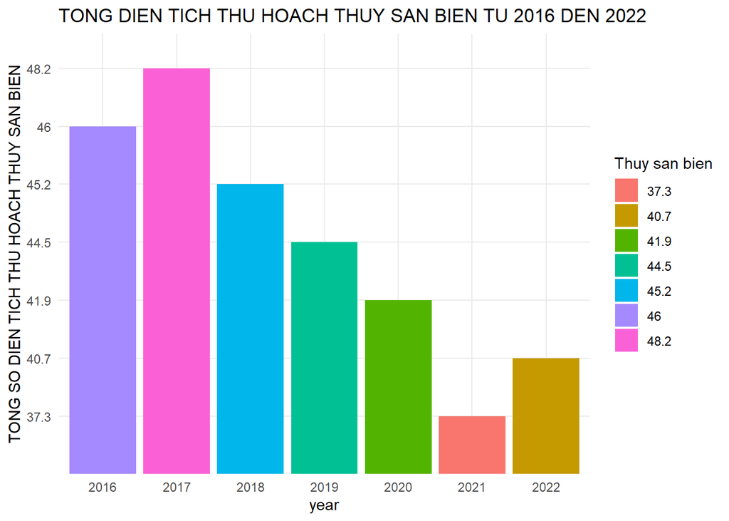

```r
#creat a bar plot for Thuy san bien
ggplot(data_02_c,aes(x=Year_Column,y = `Thuy san bien`,fill = `Thuy san bien`)) +
  geom_bar(stat = "identity") +
  labs(title = "TONG DIEN TICH THU HOACH THUY SAN BIEN TU 2016 DEN 2022",
  x ="year",
  y = "TONG SO DIEN TICH THU HOACH THUY SAN BIEN") +
  theme_minimal()
```

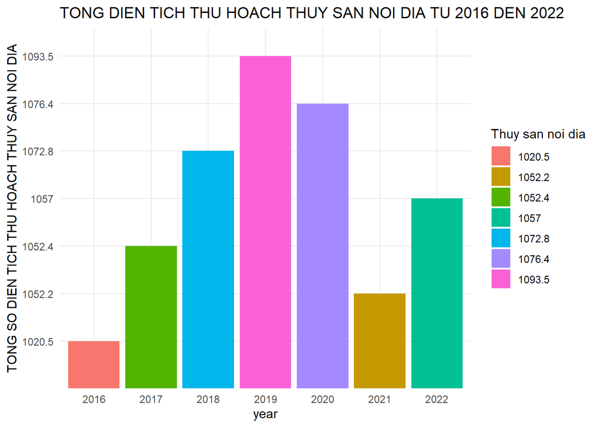

```r
#creat a bar plot for Thuy san noi dia
ggplot(data_02_c,aes(x=Year_Column,y = `Thuy san noi dia`,fill = `Thuy san noi dia`)) +
  geom_bar(stat = "identity") +
  labs(title = "TONG DIEN TICH THU HOACH THUY SAN NOI DIA TU 2016 DEN 2022",
  x ="year",
  y = "TONG SO DIEN TICH THU HOACH THUY SAN NOI DIA") +
  theme_minimal()
```

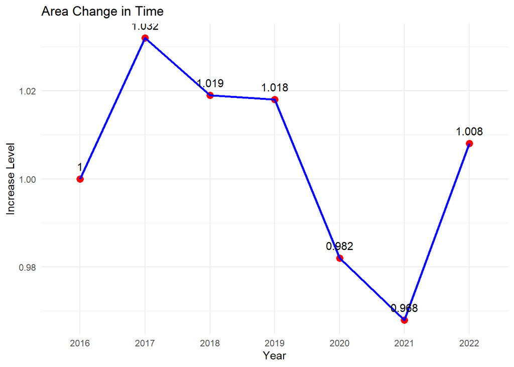

```r
#Creat increase level for Tong so
data_02_c$`TONG SO` <- as.numeric(data_02_c$`TONG SO`)
data_02_c <- data_02_c %>%
  mutate(increase_lvl = ifelse(row_number() == 1, 1, `TONG SO` / lag(`TONG SO`)))

# Convert increase level to formatted numeric values
data_02_c$increase_lvl <- round(as.numeric(data_02_c$increase_lvl), 3)

#Creat line plot for increae level in Tong so
ggplot(data_02_c, aes(x = Year_Column, y = increase_lvl, group = 1)) +
  geom_point(size = 3, color = "red") +
  geom_line(linewidth = 1, color = "blue") +
  geom_text(aes(label = increase_lvl), vjust = -1, color = "black") +  # Add labels
  labs(
    title = "Area Change in Time",
    x = "Year",
    y = "Increase Level"
  ) +
  theme_minimal()
```

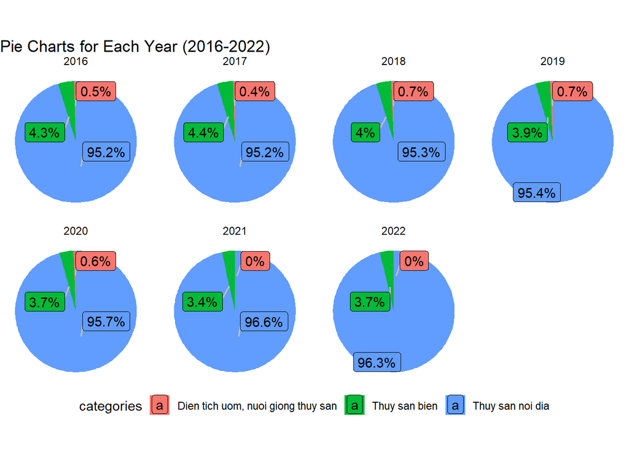

```r
#creat a data frame for piechart. bring wide to long
data_02_c1 <- data_02_c %>% select(1,3,7,11)
data_02_c1 <- data_02_c1 %>%
  pivot_longer(
    cols = c(`Thuy san bien`,`Thuy san noi dia`,`Dien tich uom, nuoi giong thuy san`),
    names_to = "categories",
    values_to = "Value"
  )
data_02_c1 <- data_02_c1 %>%
  mutate(Value = ifelse(Value =="..", 0, Value)) %>%
  mutate(as.numeric(Value))

#Cal percentage
data_02_c1 <- data_02_c1 %>%
  group_by(Year_Column) %>%
  mutate(
    Value = as.numeric(Value),
    percentage = Value / sum(Value) * 100
  )
#creat a pie plot to show the percentage of category
ggplot(data_02_c1, aes(x = "", y = percentage, fill = categories)) +
  geom_bar(stat = "identity", width = 1) +               # Create pie chart
  coord_polar(theta = "y") +                             # Convert to polar coordinates
  geom_label_repel(
    aes(label = paste0(round(percentage, 1), "%")),      # Add percentage labels
    position = position_stack(vjust = 0.5),             # Stack labels vertically
    box.padding = 0.5,                                  # Padding around the text box
    point.padding = 0.5,                                # Padding around the arrow point
    segment.color = "gray",                             # Arrow color
    segment.size = 0.7                                  # Arrow thickness
  ) +
  facet_wrap(~ Year_Column, ncol = 4) +                 # Create facets for each year
  labs(title = "Pie Charts for Each Year (2016-2022)", x = NULL, y = NULL) +
  theme_void() +                                        # Minimal theme
  theme(legend.position = "bottom")                    # Move legend to the bottom
```

#Summary chunk 2 Co the thay rang dien tich khong tang deu ma co su thay doi theo thoi gian, hien tai co giai doan tu 2019 toi 2021 dien tich giam. Note: Dien tich giam, ma nam nao gia tri cung tang, nhung ma muc tang khong co dot bien. Vay nen co the du doan rang san luong cung co giam, nhung ma khi tinh ra gia tri/ dien tich thi no van lon hon so voi cac nam truoc. Vay rang can kiem tra them ca san luong thu hoach tu nam 2016 va nam 2022.